# The Politics of Corruption

Lecture 5: The Costs of Corruption

Bogdan G. Popescu

bgpopescu@tec.mx

Tecnológico de Monterrey

## Last time: Sofia paid $40 — and it worked

- At the border, **$20** made the barrier lift and her cargo move.
- At the permit office, another **$20** got the permit the same day.
- Without those shortcuts, the delays would have cost her about **$500**.
- She paid **$40** to avoid roughly **$500** in losses.

**For Sofia, paying the bribes was rational — and made her business more efficient.**

## Then where is the cost?

**Sofia’s private calculation**

- Delay avoided: about **$500**
- Bribes paid: **$40**
- Immediate gain from paying: about **$460**

The two officials gain the $40 she pays. The money itself mostly changes pockets.

**The system-level question**

- Why was Sofia facing the $500 cost in the first place?
- Would the $500 cost still exist if officials could not collect bribes?
- What happens to a trader who cannot afford the $40 shortcut?
- What happens if thousands of firms face the same choice?

**A bribe can be privately efficient for Sofia and still be socially costly.**

## Today: where do the costs show up?

### I. Across the economy

**Does corruption make countries and firms poorer?**

### II. In public services

**What happens when money meant for roads disappears?**

### III. Across people

**Who bears the burden — and who gets shut out?**

**We move from Sofia’s private gain to corruption’s wider costs.**

# I. Costs across the economy

## Was Sofia’s $40 grease — or sand?

**The “grease” story**

- Without the two payments, delay costs her about **$500**.
- With **$40** in bribes, the cargo clears and the permit arrives the same day.
- Sofia is much better off paying than refusing.
- Corruption appears to help her overcome a slow bureaucracy.

Grease: Leff (1964); Huntington (1968). Sand: Rose-Ackerman (1978); Shleifer and Vishny (1993). Sofia is an illustration, not evidence from these studies.

**The fact that paying helps Sofia does not tell us whether the system itself is efficient.**

## Was Sofia’s $40 grease — or sand?

**The “sand” story**

- But what if officials can profit from keeping the barrier and queue slow?
- Then selling speed gives them a reason to preserve the obstacle.
- Sofia still benefits from paying — while traders who cannot pay remain stuck or stay out.

Grease: Leff (1964); Huntington (1968). Sand: Rose-Ackerman (1978); Shleifer and Vishny (1993). Sofia is an illustration, not evidence from these studies.

**The fact that paying helps Sofia does not tell us whether the system itself is efficient.**

## The pattern everyone starts from

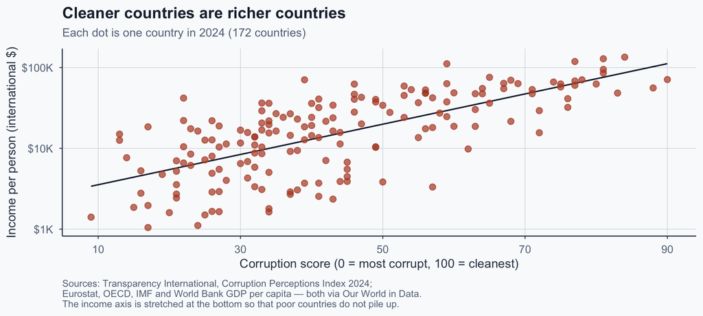

## Mauro (1995): take Sofia’s question to 67 countries

- Sofia showed us why a bribe can look like **grease** for one firm.
- Mauro asks: does that logic hold across whole economies?
- He compares **67 countries**.
- Business analysts had rated how much firms faced:
  - corruption,
  - red tape,
  - and an inefficient legal system.

**If corruption really greases the wheels, it should be especially useful where red tape is worst.**

Mauro (1995), pp. 683–687. Business International collected the institutional ratings in 1980–1983; higher scores meant better institutions.

## What would the “grease” story predict?

**If bureaucracy is already fast**

- There is little delay to bypass.
- A bribe should not help very much.

**If bureaucracy is painfully slow**

- There is lots of delay to bypass.
- This is where “speed money” should help most.

**So Mauro compares countries with more and less red tape.**

## Mauro’s world of bureaucratic efficiency

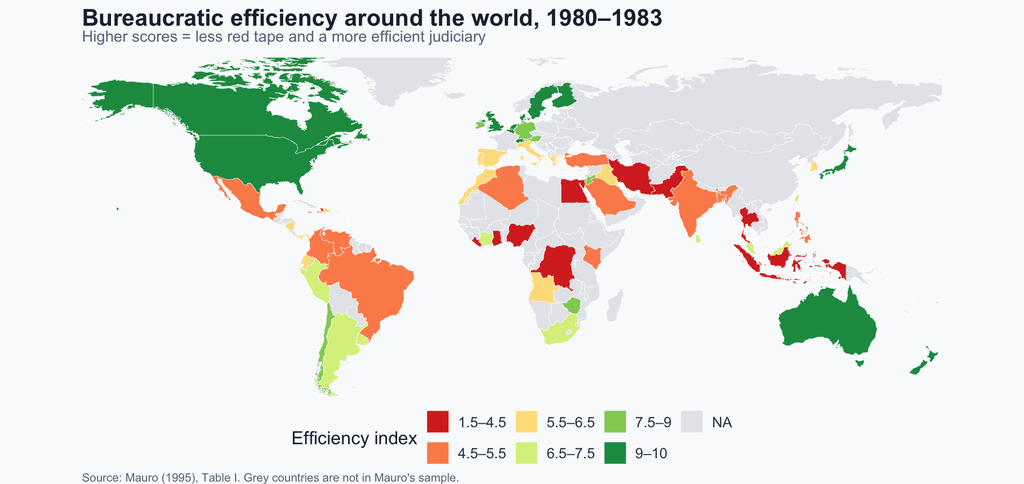

## What happens to investment as bureaucracies improve?

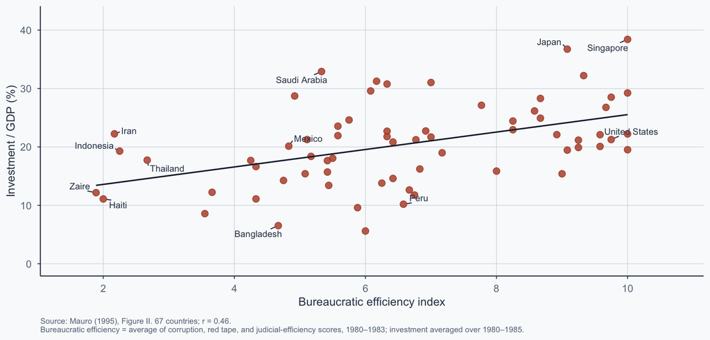

Countries with more efficient bureaucracies tended to invest more.

But this picture alone cannot tell us why.

## Does corruption help when red tape is worst?

- Mauro separates countries with **more** and **less** red tape.
- If the grease story is right, corruption should be less harmful — perhaps even helpful — where bureaucracy is slow.
- It was not.
- Less corruption was associated with **more investment in both groups**.

**The evidence does not show corruption rescuing countries from bad bureaucracy.**

A one-standard-deviation improvement in the corruption score was associated with investment about **2.9 percentage points of GDP higher**.

Mauro (1995), Table IV. The estimated relationship between corruption and investment did not differ significantly between high- and low-red-tape countries.

## But what causes what?

We observe: **Worse bureaucracy ↔︎ less investment**

That could mean:

**1. Bad bureaucracy → less investment** Bribes and red tape make firms less willing to invest.

**2. Weak economies → bad bureaucracy** Poor economic performance may make effective government harder to sustain.

**3. Something else → both** Political instability or other institutions may produce both.

**The correlation alone cannot tell us which story is right.**

## Mauro tries to get closer to causality

Mauro (1995), pp. 683, 692–698. Mauro also discusses alternative instruments and limitations of the strategy.

## The detour, in one picture

```
%%{init: {"flowchart": {"useMaxWidth": true, "nodeSpacing": 100, "rankSpacing": 95, "padding": 44, "wrappingWidth": 700, "curve": "basis"}, "themeVariables": {"fontSize": "20px", "fontFamily": "Verdana, Geneva, sans-serif"}, "markdownAutoWrap": false, "width": 1150, "height": 620}}%%
flowchart LR
  F["Ethnolinguistic split<br/>in 1960"] -->|"shapes"| I["Institutions today<br/>corruption, red tape"]
  I -->|"related to"| V["Investment today"]
  F -. "assumed: no direct route" .-> V
  classDef early fill:#1e293b,stroke:#1e293b,color:#f9fafb,stroke-width:2px;
  classDef mid fill:#f9fafb,stroke:#4a7c6f,color:#1e293b,stroke-width:2.5px;
  classDef out fill:#f9fafb,stroke:#64748b,color:#1e293b,stroke-width:2.5px;
  class F early;
  class I mid;
  class V out;
  linkStyle 2 stroke:#b44527,stroke-width:2px,stroke-dasharray:6 6;
```

**The 1960 split came first — so that arrow can only run one way.**

Author’s illustration of Mauro’s strategy. The solid path is what he can estimate. The dashed arrow is the assumption behind it: fractionalization must not reach investment by any other route. Timing rules out the reverse story; nothing rules out the dashed arrow except argument.

## From Mauro’s countries to Ugandan firms

- **Mauro** showed that cleaner bureaucracies are associated with more investment across countries.
- But that evidence was:
  - **cross-country**,
  - based on **perception measures**,
  - and still vulnerable to causal doubts.
- **Fisman and Svensson (2007)** move to the firm level.
- They ask: within one country, do firms that pay more bribes grow more slowly?

**Same question as Mauro — but now inside one economy, with direct reports from firms.**

Fisman and Svensson (2007), Introduction. The paper explicitly presents itself as a firm-level complement to the cross-country literature beginning with Mauro (1995).

## Fisman and Svensson (2007): the setup

- Survey of **243 manufacturing firms** in Uganda
- Managers were asked, confidentially, about:
  - **bribe payments**,
  - **tax payments**,
  - and firm performance
- Bribes and taxes were both measured as a **share of sales**
- Outcome: **firm growth**, especially growth in sales

So the comparison is not just **bribes versus no bribes**. It is:

**How harmful are bribes compared with an ordinary tax burden?**

Fisman and Svensson (2007), Abstract and data section. Growth is measured over 1995–1997.

## What they found

- Firms facing **higher bribe rates** grew more slowly.
- Firms facing **higher tax rates** also grew more slowly.
- But the bribe effect was much larger.
- Roughly:
  - **+1 percentage point in bribery** → about **3 percentage points less growth**
  - the effect of taxation was much smaller

**Bribery looked more damaging to firm growth than taxation.**

Fisman and Svensson (2007), Abstract. The paper reports that the bribery effect is about 2.5 to 3 times the size of the tax effect, depending on specification and treatment of outliers.

## Why can a bribe hurt more than a tax?

| A tax | A bribe |
| --- | --- |
| Known in advance | Secret and uncertain |
| Applies by rule | Depends on the official |
| Easier to budget for | Can be renegotiated or demanded again |
| Legally enforceable | No contract can be enforced in court |
| May fund public goods | Mainly buys a private shortcut |

So corruption is not simply **“a tax whose revenue disappears.”**

**It also adds uncertainty, bargaining, and repeat extraction.**

Shleifer and Vishny (1993), tested at the firm level by Fisman and Svensson (2007).

## When does grease become drag?

Back to Sofia:

Sofia’s first two bribes helped her.

But now imagine her business growing:

- more shipments;
- more inspections;
- more permits and approvals;
- more points where a payment can be demanded;
- more uncertainty about how much and when.

**A single bribe can help a firm. A system of repeated bribes can slow its growth.**

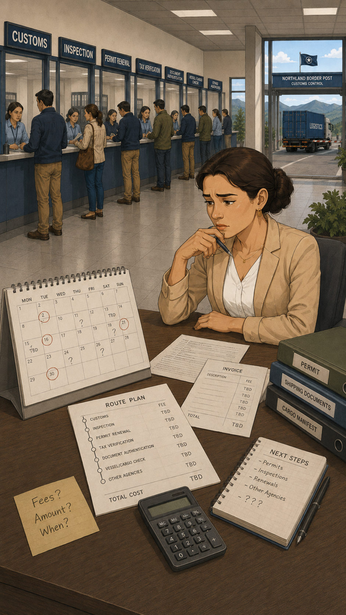

Sofia trying to plan a growing business while facing repeated official demands.

## So what?

- **Mauro:** across countries, cleaner bureaucracies are associated with more investment.
- **Fisman and Svensson:** within one country, firms paying more bribes grow more slowly.
- And where rents are large, talent can flow into capturing them rather than building things.
- Together, they suggest that corruption carries real economic costs:
  - across economies,
  - and inside firms.
- Next we move to a different kind of evidence:
  - corruption in a public project,
  - measured directly,
  - and altered experimentally.

**Next: what happens when researchers dig up the road — and some villages face audits by lottery?**

Talent diverted into rent-seeking: Murphy, Shleifer and Vishny (1991), cited by Mauro (1995).

# II. Costs in public services

## A village, a road, and a missing quarter

- A village in Java receives about **US$8,800** to surface its road
- The village reports, line by line, what it spent
- Engineers later dig into the road and measure what is actually there
- About **a quarter** of the reported spending is not in the ground

Hold that number. First: **what part is a transfer, and what part is a social loss?**

[figure not shown]

A road in Licin, East Java — one of Olken’s two study provinces.

Photo: Aryphrase, CC BY-SA 3.0, via [Wikimedia Commons](https://commons.wikimedia.org/wiki/File:Road_at_Licin,_East_Java,_Indonesia.jpg). Illustrative; not a project road from the study.

Olken (2007). We now use the case to separate money changing hands from public value that disappears.

## What exactly was lost?

```
%%{init: {"flowchart": {"useMaxWidth": true, "nodeSpacing": 105, "rankSpacing": 80, "padding": 48, "wrappingWidth": 700, "curve": "basis"}, "themeVariables": {"fontSize": "20px", "fontFamily": "Verdana, Geneva, sans-serif"}, "markdownAutoWrap": false, "width": 1150, "height": 620}}%%
flowchart LR
  S["$1,000 is<br/>diverted"] --> A["Someone else receives<br/>the $1,000"]
  S --> B["$1,000 less buys<br/>road materials"]
  B --> C["The village gets less road<br/>than it paid for"]
  classDef origin fill:#1e293b,stroke:#1e293b,color:#f9fafb,stroke-width:2px;
  classDef transfer fill:#f9fafb,stroke:#64748b,color:#1e293b,stroke-width:2.5px;
  classDef loss fill:#f9fafb,stroke:#b44527,color:#1e293b,stroke-width:2.5px;
  class S origin;
  class A transfer;
  class B,C loss;
```

**The stolen money changes hands. The social cost is that the public gets less than it paid for.**

Author’s illustration. The first branch is a transfer; the second is the loss of public value. Olken (2007) measures missing expenditures and materials, not the downstream effects of a worse road.

## Olken (2007): 608 villages in Java

- **Indonesia**, 2003–2004
- A national village-grant programme, funded by the World Bank
- **608 villages** in **Central** and **East Java**
- Most projects: surfacing a dirt road with sand, rocks and gravel

The unit is no longer a country or a firm.

It is a **village road**.

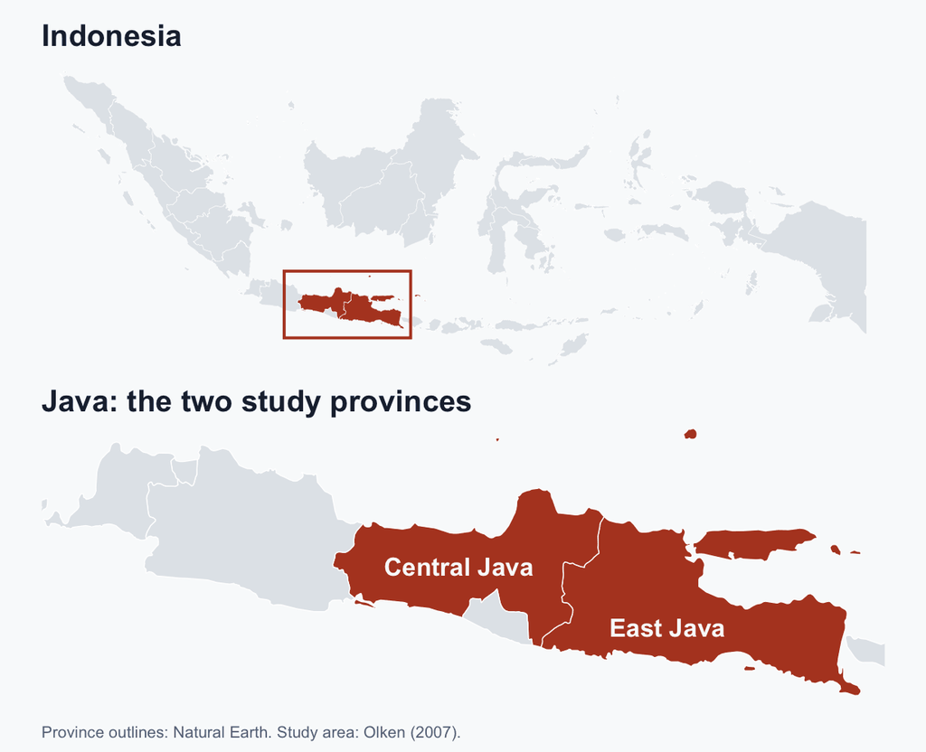

## Where does the comparison come from?

```
%%{init: {"flowchart": {"useMaxWidth": true, "nodeSpacing": 70, "rankSpacing": 78, "padding": 40, "wrappingWidth": 700, "curve": "basis"}, "themeVariables": {"fontSize": "20px", "fontFamily": "Verdana, Geneva, sans-serif"}, "markdownAutoWrap": false, "width": 1150, "height": 620}}%%
flowchart LR
  A["608 village<br/>road projects"] --> L{"Lottery"}
  L --> T["Told: an audit<br/>is certain"]
  L --> C["Ordinary oversight<br/>4% chance of an audit"]
  T --> M["Engineers measure<br/>what is in the road"]
  C --> M
  M --> D["Difference =<br/>effect of the audit"]
  classDef origin fill:#1e293b,stroke:#1e293b,color:#f9fafb,stroke-width:2px;
  classDef draw fill:#f9fafb,stroke:#b7943a,color:#1e293b,stroke-width:2.5px;
  classDef arm fill:#f9fafb,stroke:#64748b,color:#1e293b,stroke-width:2.5px;
  classDef out fill:#f9fafb,stroke:#b44527,color:#1e293b,stroke-width:2.5px;
  class A origin;
  class L draw;
  class T,C,M arm;
  class D out;
```

**Mauro needed a detour through 1960. Here, the comparison is made by a lottery.**

Olken (2007), Sections II–III. Villages were told about the audit before the project was built, so the announcement could change behaviour.

## How did they know what was really there?

```
%%{init: {"flowchart": {"useMaxWidth": true, "nodeSpacing": 45, "rankSpacing": 95, "padding": 44, "wrappingWidth": 700, "curve": "basis"}, "themeVariables": {"fontSize": "20px", "fontFamily": "Verdana, Geneva, sans-serif"}, "markdownAutoWrap": false, "width": 1150, "height": 620}}%%
flowchart LR
  R["The village's own<br/>spending report"] --> G["Compare"]
  S["Core samples dug<br/>out of the road"] --> G
  W["Interviews with<br/>the workers"] --> G
  G --> X["About 24% of reported<br/>spending cannot be found"]
  classDef claim fill:#1e293b,stroke:#1e293b,color:#f9fafb,stroke-width:2px;
  classDef check fill:#f9fafb,stroke:#4a7c6f,color:#1e293b,stroke-width:2.5px;
  classDef mid fill:#f9fafb,stroke:#64748b,color:#1e293b,stroke-width:2.5px;
  classDef hot fill:#b44527,stroke:#b44527,color:#f9fafb,stroke-width:2.5px;
  class R claim;
  class S,W check;
  class G mid;
  class X hot;
```

**Not an expert’s impression of a country. A number you can dig out of the ground.**

Olken (2007), pp. 202–203. Engineers took core samples from the finished road, priced materials with local suppliers, and asked workers what they had been paid.

## Audits cut the theft

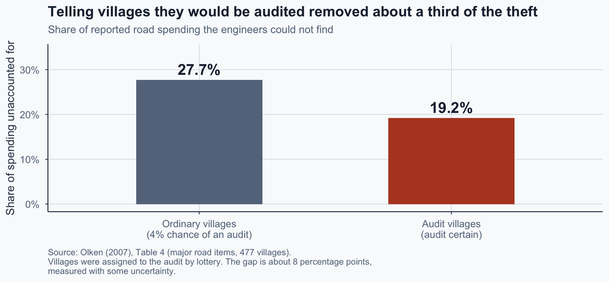

## What we learned, and what we did not

**What we learned**

- The comparison was made by a lottery, not by choice
- Announced audits cut missing spending by about a third
- The theft prevented was worth more than the audits cost

**What we did not learn**

- Audits did not end corruption: about a fifth still went missing
- Village accountability meetings had no average effect
- One programme, one country, one kind of road

**Top-down audits moved the number. Bottom-up village meetings, on average, did not.**

Olken (2007), Sections V and VI. Theft prevented ≈ $468 per village against an audit cost of ≈ $335.

# III. When corruption becomes exclusion

## Sofia could pay. What if you cannot?

- Sofia faced a **$40 shortcut** and could afford it.
- Paying was privately rational: she avoided about **$500** in losses.
- But dealing with the state is not always a choice.
- And not everyone can buy the shortcut.

**The same payment is a shortcut for one person and a barrier for another.**

## How corruption becomes a personal cost

```
%%{init: {"flowchart": {"useMaxWidth": true, "nodeSpacing": 45, "rankSpacing": 75, "padding": 40, "wrappingWidth": 700, "curve": "basis"}, "themeVariables": {"fontSize": "20px", "fontFamily": "Verdana, Geneva, sans-serif"}, "markdownAutoWrap": false, "width": 1150, "height": 620}}%%
flowchart LR
  M["Misfortune, or<br/>ordinary business"] --> S["You need<br/>a public office"]
  S --> B["An official asks<br/>for a payment"]
  B --> P["You can pay"]
  B --> N["You cannot pay"]
  P --> A["You get the service,<br/>and pay extra"]
  N --> X["You delay, drop it,<br/>or go without"]
  classDef origin fill:#1e293b,stroke:#1e293b,color:#f9fafb,stroke-width:2px;
  classDef step fill:#f9fafb,stroke:#64748b,color:#1e293b,stroke-width:2.5px;
  classDef pay fill:#f9fafb,stroke:#4a7c6f,color:#1e293b,stroke-width:2.5px;
  classDef gone fill:#f9fafb,stroke:#b44527,color:#1e293b,stroke-width:2.5px;
  class M origin;
  class S,B step;
  class P,A pay;
  class N,X gone;
```

**Three separate questions: who ends up at the counter, what the payment costs them, and what happens if they walk away.**

## Exercise · You are in charge

Your city has a corruption problem. Your group controls **$1 million**.

**Groups of four — 5 minutes.** Pick **one** area you care about:

Police · Hospitals · Permits · Construction · Universities · your own

**Then answer three questions:**

1. What is the **biggest harm** corruption causes there?
2. What **one thing** would you spend the million on to reduce it?
3. What from today makes you think that would **work**?

## Report back — 30 seconds each

**We chose** ______

**The main problem is** ______

**We would spend the money on** ______ **because** ______

**Then we vote: which proposal would you actually fund?**

No group may vote for itself.

## One puzzle, four answers

- **Sofia:** a bribe can be privately beneficial.
- **Firms and economies:** corruption can coexist with lower investment and slower growth.
- **Public services:** diverted resources can leave society with less than it paid for.
- **Households:** unofficial payments can turn access to the state into exclusion.

**The cost of corruption is not only the money that changes hands. It is what the system makes people stop doing.**

Next session: the United States — how patronage was built, and how reform took the favour out of politicians’ hands.

## References (1 of 3)

Fisman, R., & Svensson, J. (2007). Are corruption and taxation really harmful to growth? Firm level evidence. *Journal of Development Economics, 83*(1), 63–75. https://doi.org/10.1016/j.jdeveco.2005.09.009

Hunt, J. (2007). How corruption hits people when they are down. *Journal of Development Economics, 84*(2), 574–589. https://doi.org/10.1016/j.jdeveco.2007.02.003

Hunt, J., & Laszlo, S. (2012). Is bribery really regressive? Bribery’s costs, benefits, and mechanisms. *World Development, 40*(2), 355–372. https://doi.org/10.1016/j.worlddev.2011.07.015

Huntington, S. P. (1968). *Political order in changing societies*. Yale University Press.

Leff, N. H. (1964). Economic development through bureaucratic corruption. *American Behavioral Scientist, 8*(3), 8–14. https://doi.org/10.1177/000276426400800303

## References (2 of 3)

Mauro, P. (1995). Corruption and growth. *The Quarterly Journal of Economics, 110*(3), 681–712. https://doi.org/10.2307/2946696

Murphy, K. M., Shleifer, A., & Vishny, R. W. (1991). The allocation of talent: Implications for growth. *The Quarterly Journal of Economics, 106*(2), 503–530.

Olken, B. A. (2007). Monitoring corruption: Evidence from a field experiment in Indonesia. *Journal of Political Economy, 115*(2), 200–249. https://doi.org/10.1086/517935

Olken, B. A. (2009). Corruption perceptions vs. corruption reality. *Journal of Public Economics, 93*(7–8), 950–964. https://doi.org/10.1016/j.jpubeco.2009.03.001

Rose-Ackerman, S. (1978). *Corruption: A study in political economy*. Academic Press.

## References (3 of 3)

Shleifer, A., & Vishny, R. W. (1993). Corruption. *The Quarterly Journal of Economics, 108*(3), 599–617. https://doi.org/10.2307/2118402

Transparency International. (2025). *Corruption Perceptions Index 2024*. https://www.transparency.org/en/cpi/2024

Treisman, D. (2007). What have we learned about the causes of corruption from ten years of cross-national empirical research? *Annual Review of Political Science, 10*, 211–244. https://doi.org/10.1146/annurev.polisci.10.081205.095418